# Release Notes for STM32 Secure Engine

Copyright © 2017 STMicroelectronics

[figure not shown]

# License

This software component is licensed by ST under Ultimate Liberty license SLA0044, the “License”;

You may not use this file except in compliance with the License.

You may obtain a copy of the License at: SLA0044

# Purpose

STM32 Secure Engine middleware provides a protected environment to manage all critical data and operations (such as cryptography operations accessing firmware encryption key, and others).

Protected code and data are accessible through a single entry point (call gate mechanism) and it is therefore not possible to run or access any SE code or data without passing through it, otherwise a system reset is generated.

Depending on hardware two different mechanisms are provided :

- Firewall-based Secure Engine Isolation : The firewall is opened or closed using a specific “call gate” mechanism: a single entry point (placed at the 2nd word of the Code segment base address) must be used to open the gate and to execute the code protected by the firewall. If the protected code is accessed without passing through the call gate mechanism then a system reset is generated.

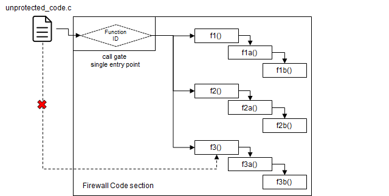

Firewall-based isolation

- MPU-based Secure Engine Isolation : The MPU-based Secure Engine isolation relies on the concept of privileged and unprivileged levels of software execution. The software must run in unprivileged level of execution by default (when SBSFU or the User Application is running), except for very specific actions like platform initialization or interrupt handling.

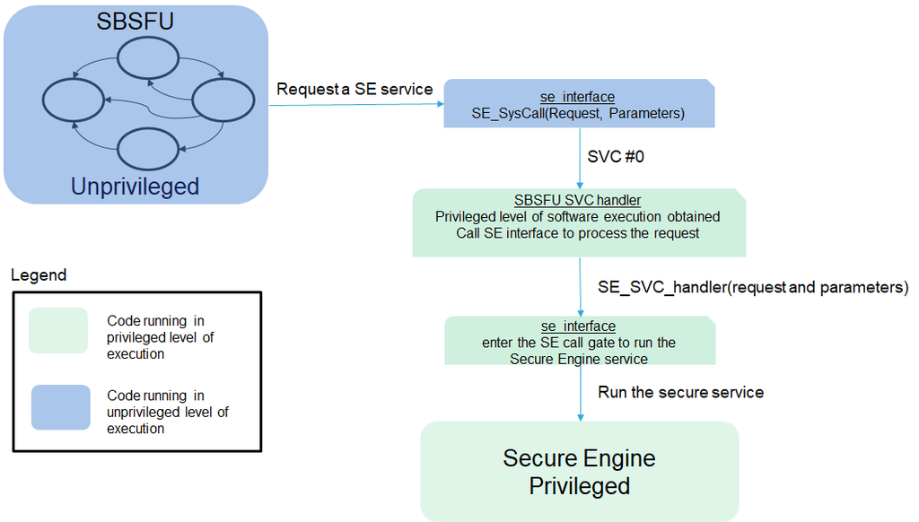

MPU-based isolation

STM32 Secure Engine middleware provides the runtime services required to handle the Firmware Image State. A Firmware Image goes through different states during its lifecycle to support Over The Air update (OTA).

[figure not shown]

Firmware Image States

For more details, refer to [UM2262](https://www.st.com/st-web-ui/static/active/en/resource/technical/document/user_manual/DM00414687.pdf), AppendixA : Getting started with X-CUBE-SBSFU expansion package

# Update History

v2.0.0-aws_2.0.0 / 12-March-2020

## Main Changes

**Firmware Image State support**

Implement the functions required by the bootloader and the application to get and set the firmware image state.

prepareimage.py utility updated to support this image state:  
- inject the “New” state when creating a standard .sfb file  
- inject the “Valid” state when creating a “big binary” (SBSFU+userApplication binary)

v2.0.0 / 13-July-2019

## Main Changes

**General improvements (software counter measures) against software attacks and against basic hardware faults injection**

Secure Engine extended with **Key Management Services**, replacing former secure engine crypto services when KMS feature is enabled

Add SE_IMG_Erase API to be able to erase slot #0 header: mandatory for NUCLEO-L073RZ (specific behavior of STM32L0 flash interface : writing instructions during erasing sequence)

prepareimage.py utility updated to support :  
- partial image update  
- pairing keys, for communication with STSAFE-A100

## Known Limitations

None

## Backward Compatibility

Break of compatibility with V1.2.0

V1.2.0 / 14-December-2018

## Main Changes

prepareimage/key/translate_key scripts improvements :  
- Quicker execution timing.  
- Support of big elf in order to be able to flash SBSFU+ UserApp from IDE : refer to AN5056 for more details.  
- Adaptation for ARM V6M architecture (cortex MO+)  
- Remove support of cipher text stealing : 16 bytes alignment ensure with linker command files during UserAppbuild process.

Add mapping_export.h for IAR and SW4STM32 tool chains to avoid mapping symbols inclusion into *.c files.

Add support of SE service calls from unprivileged part of application : SE_APP_GET_ACTIVE_FW_INFO.

Security controls added :  
- Check the mapping of the data given as parameters toSecure Engine services (SE_BufferCheck_SBSFU() /SE_BufferCheck_in_se_ram()).  
- Clean Secure Engine RAM data (SE_LL_CORE_Cleanup())when leaving SBSFU (SE_LockRestrictServices()).

V1.1.0 / 20-April-2018

## Main Changes

Multiple crypto scheme implemented under compilation switch (se_crypto_config.h) :  
- SECBOOT_AES128_GCM_AES128_GCM_AES128_GCM: symmetric crypto.  
- SECBOOT_ECCDSA_WITH_AES128_CBC_SHA256(default config) : asymmetric crypto with encrypted (AES128-CBC)Firmware.  
- SECBOOT_ECCDSA_WITHOUT_ENCRYPT_SHA256 : asymmetric crypto without firmware encryption.

Build process modification : scripts added in Utilities/KeysAndImages called during :  
- SECoreBin build for key generation.  
- UserApp build for firmware encryption.  
- Windows executable version of the python scripts available : This is now the default tooling for pre/post build actions (so python not mandatory any more)

Secure Engine now using its own stack inside protected area

Files structure updated to provide more feature modularity and feature customization flexibility

V1.0.0 / 1-December-2017